# ST 558 Project 1

Bennett McAuley

## Overview

The purpose of this project was to write functions to manipulate and process data that come in various forms. The data consisted of `.csv` files with information from the Census Bureau.

The first section will go through the data processing ad hoc on the first portion of the bureau data. Following, the method is repeated via function calls–that will be defined–on the second portion of the data set. Finally, we will define a function for plotting to apply on data sets that were not used during processing to ensure the logic generalizes.

### Data Processing

First, we need the data! The `readr` library is used to read in one section of the data.

```r
library(readr)
sheet1 <- read_csv("https://www4.stat.ncsu.edu/~online/datasets/EDU01a.csv")
```

Of the columns, we only need to select `Area_name` (renamed to `area_name`), `STCOU`, and the ones that end in “D”:

```r
sheet1 <- plyr::rename(sheet1, c("Area_name" = "area_name"))

sheet1 %>%
  select(area_name, STCOU, ends_with("D"))
```

| area_name | STCOU | EDU010187D | EDU010188D | EDU010189D | EDU010190D | EDU010191D | EDU010192D | EDU010193D | EDU010194D | EDU010195D | EDU010196D |
| --- | --- | --- | --- | --- | --- | --- | --- | --- | --- | --- | --- |
| UNITED STATES | 00000 | 40024299 | 39967624 | 40317775 | 40737600 | 41385442 | 42088151 | 42724710 | 43369917 | 43993459 | 44715737 |
| ALABAMA | 01000 | 733735 | 728234 | 730048 | 728252 | 725541 | 726150 | 728014 | 730509 | 727989 | 736825 |
| Autauga, AL | 01001 | 6829 | 6900 | 6920 | 6847 | 7008 | 7137 | 7152 | 7381 | 7568 | 7834 |
| Baldwin, AL | 01003 | 16417 | 16465 | 16799 | 17054 | 17479 | 17983 | 18735 | 19384 | 19961 | 20699 |
| Barbour, AL | 01005 | 5071 | 5098 | 5068 | 5156 | 5173 | 5252 | 5135 | 5111 | 5017 | 5053 |
| Bibb, AL | 01007 | 3557 | 3508 | 3571 | 3621 | 3652 | 3564 | 3565 | 3552 | 3539 | 3656 |
| Blount, AL | 01009 | 7319 | 7223 | 7205 | 7209 | 7155 | 7150 | 7210 | 7300 | 7421 | 7622 |
| Bullock, AL | 01011 | 2014 | 1980 | 1985 | 1983 | 1985 | 2023 | 2010 | 2011 | 1972 | 1989 |
| Butler, AL | 01013 | 4640 | 4582 | 4610 | 4591 | 4544 | 4476 | 4444 | 4348 | 4300 | 4173 |
| Calhoun, AL | 01015 | 20939 | 20923 | 20907 | 20849 | 20768 | 20485 | 20510 | 20110 | 19619 | 19665 |

[output cut: 3188 more lines]

For whatever reason, renaming the column did not work with the chaining method, even with explicitly calling out the library. So I used the workaround shown above. It works for what we needed, so we will move on.

Next, we convert the data into long format where each row has only one enrollment value per `area_name`. To accomplish this, we tell the `pivot_longer` function all of the columns that end in “D” should be pivoted. Those are named `survey` with the values named `enrollment`.

```r
sheet1 %>%
  select(area_name, STCOU, ends_with("D")) %>%
  pivot_longer(cols = c(ends_with("D")), names_to = "survey", values_to = "enrollment")
```

| area_name | STCOU | survey | enrollment |
| --- | --- | --- | --- |
| UNITED STATES | 00000 | EDU010187D | 40024299 |
| UNITED STATES | 00000 | EDU010188D | 39967624 |
| UNITED STATES | 00000 | EDU010189D | 40317775 |
| UNITED STATES | 00000 | EDU010190D | 40737600 |
| UNITED STATES | 00000 | EDU010191D | 41385442 |
| UNITED STATES | 00000 | EDU010192D | 42088151 |
| UNITED STATES | 00000 | EDU010193D | 42724710 |
| UNITED STATES | 00000 | EDU010194D | 43369917 |
| UNITED STATES | 00000 | EDU010195D | 43993459 |
| UNITED STATES | 00000 | EDU010196D | 44715737 |

[output cut: 9990 more lines]

Now, we parse out the years of the surveys and the first seven characters–three alphabetical and four digits–to create two new variables. Each are separated using an index (here it’s 7 since that’s where we want to split), so the year is retained in the latter column. Then the `mutate` function, with help from the `substr` and `as.Date` functions, captures the last two year digits, converts into a date to be recognized and converted correctly, formatted to only have the year shown, and finally converted to a numeric variable. Complicated, but after much trial and error, it proved to be a sustainable solution!

```r
sheet1 %>%
  select(area_name, STCOU, ends_with("D")) %>%
  pivot_longer(cols = c(ends_with("D")), names_to = "survey", values_to = "enrollment") %>%
  separate(survey, into = c("measurement", "year"), sep = 7, convert = TRUE) %>%
  mutate(year = as.numeric(format(as.Date(substr(year, 1, 2), "%y"), format = "%Y")))
```

| area_name | STCOU | measurement | year | enrollment |
| --- | --- | --- | --- | --- |
| UNITED STATES | 00000 | EDU0101 | 1987 | 40024299 |
| UNITED STATES | 00000 | EDU0101 | 1988 | 39967624 |
| UNITED STATES | 00000 | EDU0101 | 1989 | 40317775 |
| UNITED STATES | 00000 | EDU0101 | 1990 | 40737600 |
| UNITED STATES | 00000 | EDU0101 | 1991 | 41385442 |
| UNITED STATES | 00000 | EDU0101 | 1992 | 42088151 |
| UNITED STATES | 00000 | EDU0101 | 1993 | 42724710 |
| UNITED STATES | 00000 | EDU0101 | 1994 | 43369917 |
| UNITED STATES | 00000 | EDU0101 | 1995 | 43993459 |
| UNITED STATES | 00000 | EDU0101 | 1996 | 44715737 |

[output cut: 9990 more lines]

From here, we create two data sets for county level data and state level data. First, the manipulations done on the data thus far have been saved to a new object `clean_sheet`. The county data is generated using `grepl` to find and subset to rows that contain the format “County Name, DD” for `area_name`. The state data is generated using the negation of that logic.

To complete this step, we add a `county` class to the `county_data` tibble and do the same for the `state_data` tibble with a `state` class.

```r
clean_sheet <- sheet1 %>%
  select(area_name, STCOU, ends_with("D")) %>%
  pivot_longer(cols = c(ends_with("D")), names_to = "survey", values_to = "enrollment") %>%
  separate(survey, into = c("measurement", "year"), sep = 7, convert = TRUE) %>%
  mutate(year = as.numeric(format(as.Date(substr(year, 1, 2), "%y"), format = "%Y")))

county_data <- clean_sheet %>%
  filter(grepl(pattern = ", \\w\\w", area_name))

state_data <- clean_sheet %>%
  filter(!grepl(pattern = ", \\w\\w", area_name))

class(county_data) <- c("county", class(county_data))
class(state_data) <- c("state", class(state_data))
```

For the `county_data` tibble, we create a new variable for the state (appropriately named `state`) each of the county measurements correspond to using `sub`. Reason being, we don’t have to worry about using indices for the varying lengths of the counties, just needing to find the `,`, and capturing what comes after that. Also a good excuse to practice more pattern matching functions.

```r
county_data %>%
  mutate(state = sub('.*, ', '', area_name))
```

| area_name | STCOU | measurement | year | enrollment | state |
| --- | --- | --- | --- | --- | --- |
| Autauga, AL | 01001 | EDU0101 | 1987 | 6829 | AL |
| Autauga, AL | 01001 | EDU0101 | 1988 | 6900 | AL |
| Autauga, AL | 01001 | EDU0101 | 1989 | 6920 | AL |
| Autauga, AL | 01001 | EDU0101 | 1990 | 6847 | AL |
| Autauga, AL | 01001 | EDU0101 | 1991 | 7008 | AL |
| Autauga, AL | 01001 | EDU0101 | 1992 | 7137 | AL |
| Autauga, AL | 01001 | EDU0101 | 1993 | 7152 | AL |
| Autauga, AL | 01001 | EDU0101 | 1994 | 7381 | AL |
| Autauga, AL | 01001 | EDU0101 | 1995 | 7568 | AL |
| Autauga, AL | 01001 | EDU0101 | 1996 | 7834 | AL |

[output cut: 9990 more lines]

For the `state_data` tibble, we create a variable `division` that corresponds to the Census Bureau-designated divisions for the states, of which there are nine (*Note: written out mostly for my own reference and to easily copy/paste to the code*):

1. New England (Connecticut, Maine, Massachusetts, New Hampshire, Rhode Island, Vermont)
2. Mid-Atlantic (New Jersey, New York, Pennsylvania)
3. East North Central (Illinois, Indiana, Michigan, Ohio, Wisconsin)
4. West North Central (Iowa, Kansas, Minnesota, Missouri, Nebraska, North Dakota, South Dakota)
5. South Atlantic (Delaware, Florida, Georgia, Maryland, North Carolina, South Carolina, Virginia, District of Columbia, West Virginia)
6. East South Central (Alabama, Kentucky, Mississippi, Tennessee)
7. West South Central (Arkansas, Louisiana, Oklahoma, Texas)
8. Mountain (Arizona, Colorado, Idaho, Montana, New Mexico, Nevada, Utah, Wyoming)
9. Pacific (Alaska, California, Hawaii, Oregon, Washington)

The `%in%` operator makes this task simple, but unfortunately, no less tedious for writing out the conditions! Any non-state areas that don’t belong to a division (United States, mainly) are returned as `ERROR`.

```r
state_data %>%
  mutate(division = case_when(area_name %in% c("CONNECTICUT", "MAINE", "MASSACHUSETTS", "NEW HAMPSHIRE", "RHODE ISLAND", "VERMONT") ~ "NEW ENGLAND",
                              area_name %in% c("NEW JERSEY", "NEW YORK", "PENNSYLVANIA") ~ "MID-ALTANTIC",
                              area_name %in% c("ILLINOIS", "INDIANA", "MICHIGAN", "OHIO", "WISCONSIN") ~ "EAST N. CENTRAL",
                              area_name %in% c("IOWA", "KANSAS", "MINNESOTA", "MISSOURI", "NEBRASKA", "NORTH DAKOTA", "SOUTH DAKOTA") ~ "WEST N. CENTRAL",
                              area_name %in% c("DELAWARE", "FLORIDA", "GEORGIA", "MARYLAND", "NORTH CAROLINA", "SOUTH CAROLINA", "VIRGINIA", "DISTRICT OF COLUMBIA", "WEST VIRGINIA") ~ "S. ATLANTIC",
                              area_name %in% c("ALABAMA", "KENTUCKY", "MISSISSIPPI", "TENNESSEE") ~ "EAST S. CENTRAL",
                              area_name %in% c("ARKANSAS", "LOUISIANA", "OKLAHOMA", "TEXAS") ~ "WEST S. CENTRAL",
                              area_name %in% c("ARIZONA", "COLORADO", "IDAHO", "MONTANA", "NEW MEXICO", "NEVADA", "UTAH", "WYOMING") ~ "MOUNTAIN",
                              area_name %in% c("ALASKA", "CALIFORNIA", "HAWAII", "OREGON", "WASHINGTON") ~ "PACIFIC",
                              TRUE ~ "ERROR")
)
```

| area_name | STCOU | measurement | year | enrollment | division |
| --- | --- | --- | --- | --- | --- |
| UNITED STATES | 00000 | EDU0101 | 1987 | 40024299 | ERROR |
| UNITED STATES | 00000 | EDU0101 | 1988 | 39967624 | ERROR |
| UNITED STATES | 00000 | EDU0101 | 1989 | 40317775 | ERROR |
| UNITED STATES | 00000 | EDU0101 | 1990 | 40737600 | ERROR |
| UNITED STATES | 00000 | EDU0101 | 1991 | 41385442 | ERROR |
| UNITED STATES | 00000 | EDU0101 | 1992 | 42088151 | ERROR |
| UNITED STATES | 00000 | EDU0101 | 1993 | 42724710 | ERROR |
| UNITED STATES | 00000 | EDU0101 | 1994 | 43369917 | ERROR |
| UNITED STATES | 00000 | EDU0101 | 1995 | 43993459 | ERROR |
| UNITED STATES | 00000 | EDU0101 | 1996 | 44715737 | ERROR |

[output cut: 520 more lines]

Back to top

### Function Definitions

Now we will repeat the data processing on the second component of the data, but this time using functions! Each step or set of steps will have their own functions defined to accomplish the tasks, and a wrapper function to put it all together and execute with a single call!

The first function `csv.input` returns the data set that is read in. The `link` is the only variable for it to take.

```r
csv.input <- function(link) {
  library(readr)
  return(read_csv(link))
}
```

The second function `select.pivot`, reflects steps 1 & 2. It returns a tibble with the columns we’re interested in from the data set in long format. This function takes two variables:

- `tibble`: The name of the object returned from `csv.input`
- `valname`: The name of the values for the generated column after pivoting (default is `enrollment`)

```r
select.pivot <- function(tibble, valname = "enrollment") {
  tibble <- plyr::rename(tibble, c("Area_name" = "area_name"))

  tibble %>%
    select(area_name, STCOU, ends_with("D")) %>%
    pivot_longer(cols = c(ends_with("D")), names_to = "survey", values_to = valname)
}
```

The third function `survey.split` reflects step 3. It takes the returned object from `select.pivot` and creates the new variables that reflect the survey measurement code and year from splitting `survey`.

```r
survey.split <- function(tibble) {
  tibble %>%
    separate(survey, into = c("measurement", "year"), sep = 7, convert = TRUE) %>%
    mutate(year = as.numeric(format(as.Date(substr(year, 1, 2), "%y"), format = "%Y")))
}
```

The fourth function `add.state` reflects step 5. It takes a single variable `county_lvl` for the tibble with the county level data, and creates the variable for states from `area_name`.

```r
add.state <- function(county_lvl) {
  county_lvl %>%
  mutate(state = sub('.*, ', '', area_name))
}
```

The fifth function `add.division` reflects step 6. It takes the variable `state_lvl` for the tibble with the state level data, and creates the variable for divisions from `area_name`.

```r
add.division <- function(state_lvl) {
  state_lvl %>%
  mutate(division = case_when(area_name %in% c("CONNECTICUT", "MAINE", "MASSACHUSETTS", "NEW HAMPSHIRE", "RHODE ISLAND", "VERMONT") ~ "NEW ENGLAND",
                              area_name %in% c("NEW JERSEY", "NEW YORK", "PENNSYLVANIA") ~ "MID-ALTANTIC",
                              area_name %in% c("ILLINOIS", "INDIANA", "MICHIGAN", "OHIO", "WISCONSIN") ~ "EAST N. CENTRAL",
                              area_name %in% c("IOWA", "KANSAS", "MINNESOTA", "MISSOURI", "NEBRASKA", "NORTH DAKOTA", "SOUTH DAKOTA") ~ "WEST N. CENTRAL",
                              area_name %in% c("DELAWARE", "FLORIDA", "GEORGIA", "MARYLAND", "NORTH CAROLINA", "SOUTH CAROLINA", "VIRGINIA", "DISTRICT OF COLUMBIA", "WEST VIRGINIA") ~ "S. ATLANTIC",
                              area_name %in% c("ALABAMA", "KENTUCKY", "MISSISSIPPI", "TENNESSEE") ~ "EAST S. CENTRAL",
                              area_name %in% c("ARKANSAS", "LOUISIANA", "OKLAHOMA", "TEXAS") ~ "WEST S. CENTRAL",
                              area_name %in% c("ARIZONA", "COLORADO", "IDAHO", "MONTANA", "NEW MEXICO", "NEVADA", "UTAH", "WYOMING") ~ "MOUNTAIN",
                              area_name %in% c("ALASKA", "CALIFORNIA", "HAWAII", "OREGON", "WASHINGTON") ~ "PACIFIC",
                              TRUE ~ "ERROR")
)
}
```

The sixth and final function before implementation of the wrapper, `create.data`, reflects step 4. It takes the returned object from `survey.split` and splits the data into county and state level sets. Then, it adds identically named classes to both. Finally, it calls `add.state` and `add.division` to complete the processing and returns the data sets in a list.

```r
create.data <- function(tibble) {
county_lvl <- tibble %>%
  filter(grepl(pattern = ", \\w\\w", area_name))

state_lvl <- tibble %>%
  filter(!grepl(pattern = ", \\w\\w", area_name))

class(county_lvl) <- c("county", class(county_lvl))
class(state_lvl) <- c("state", class(state_lvl))


return(list(add.state(county_lvl), add.division(state_lvl)))
}
```

Now we will put all of the functions together into one wrapper function, called `data.wrap`. It takes the `url` and `var` (same function as `valname`) for its inputs, calls the functions defined, and returns the two tibbles.

```r
data.wrap <- function(url, var) {
  t <- csv.input(url)
  u <- select.pivot(t, var)
  v <- survey.split(u)
  w <- create.data(v)

  return(w)
}
```

To ensure the work done thus far is correct, we call the function twice on the `.csv` files we have encountered thus far.

```r
data.wrap("https://www4.stat.ncsu.edu/~online/datasets/EDU01a.csv", var = "enrollment")
```

```
## [[1]]
## # A tibble: 31,450 × 6
##    area_name   STCOU measurement  year enrollment state
##    <chr>       <chr> <chr>       <dbl>      <dbl> <chr>
##  1 Autauga, AL 01001 EDU0101      1987       6829 AL
##  2 Autauga, AL 01001 EDU0101      1988       6900 AL
##  3 Autauga, AL 01001 EDU0101      1989       6920 AL
##  4 Autauga, AL 01001 EDU0101      1990       6847 AL
##  5 Autauga, AL 01001 EDU0101      1991       7008 AL
##  6 Autauga, AL 01001 EDU0101      1992       7137 AL
##  7 Autauga, AL 01001 EDU0101      1993       7152 AL
##  8 Autauga, AL 01001 EDU0101      1994       7381 AL
##  9 Autauga, AL 01001 EDU0101      1995       7568 AL
## 10 Autauga, AL 01001 EDU0101      1996       7834 AL
## # … with 31,440 more rows
##
## [[2]]
## # A tibble: 530 × 6
##    area_name     STCOU measurement  year enrollment division
##    <chr>         <chr> <chr>       <dbl>      <dbl> <chr>
##  1 UNITED STATES 00000 EDU0101      1987   40024299 ERROR
##  2 UNITED STATES 00000 EDU0101      1988   39967624 ERROR
##  3 UNITED STATES 00000 EDU0101      1989   40317775 ERROR
##  4 UNITED STATES 00000 EDU0101      1990   40737600 ERROR
##  5 UNITED STATES 00000 EDU0101      1991   41385442 ERROR
##  6 UNITED STATES 00000 EDU0101      1992   42088151 ERROR
##  7 UNITED STATES 00000 EDU0101      1993   42724710 ERROR
##  8 UNITED STATES 00000 EDU0101      1994   43369917 ERROR
##  9 UNITED STATES 00000 EDU0101      1995   43993459 ERROR
## 10 UNITED STATES 00000 EDU0101      1996   44715737 ERROR
## # … with 520 more rows
```

```r
data.wrap("https://www4.stat.ncsu.edu/~online/datasets/EDU01b.csv", var = "enrollment")
```

```
## [[1]]
## # A tibble: 31,450 × 6
##    area_name   STCOU measurement  year enrollment state
##    <chr>       <chr> <chr>       <dbl>      <dbl> <chr>
##  1 Autauga, AL 01001 EDU0101      1997       8099 AL
##  2 Autauga, AL 01001 EDU0101      1998       8211 AL
##  3 Autauga, AL 01001 EDU0101      1999       8489 AL
##  4 Autauga, AL 01001 EDU0102      2000       8912 AL
##  5 Autauga, AL 01001 EDU0102      2001       8626 AL
##  6 Autauga, AL 01001 EDU0102      2002       8762 AL
##  7 Autauga, AL 01001 EDU0152      2003       9105 AL
##  8 Autauga, AL 01001 EDU0152      2004       9200 AL
##  9 Autauga, AL 01001 EDU0152      2005       9559 AL
## 10 Autauga, AL 01001 EDU0152      2006       9652 AL
## # … with 31,440 more rows
##
## [[2]]
## # A tibble: 530 × 6
##    area_name     STCOU measurement  year enrollment division
##    <chr>         <chr> <chr>       <dbl>      <dbl> <chr>
##  1 UNITED STATES 00000 EDU0101      1997   44534459 ERROR
##  2 UNITED STATES 00000 EDU0101      1998   46245814 ERROR
##  3 UNITED STATES 00000 EDU0101      1999   46368903 ERROR
##  4 UNITED STATES 00000 EDU0102      2000   46818690 ERROR
##  5 UNITED STATES 00000 EDU0102      2001   47127066 ERROR
##  6 UNITED STATES 00000 EDU0102      2002   47606570 ERROR
##  7 UNITED STATES 00000 EDU0152      2003   48506317 ERROR
##  8 UNITED STATES 00000 EDU0152      2004   48693287 ERROR
##  9 UNITED STATES 00000 EDU0152      2005   48978555 ERROR
## 10 UNITED STATES 00000 EDU0152      2006   49140702 ERROR
## # … with 520 more rows
```

Success! Now we write a small function `lvl.combine` that takes the results of the calls above and combines the tibbles such that they are homogeneous (i.e. county level A with county level B).

```r
lvl.combine <- function(tA, tB) {

  all_county <- dplyr::bind_rows(tA[[1]], tB[[1]])
  all_state <- dplyr::bind_rows(tA[[2]], tB[[2]])

  return(list(all_county, all_state))
}
```

Back to top

### Generic Functions for Summarizing

Our data sets have their own classes that we can used to write a custom `plot` function. First we will define a function for state, `plot.state`. It takes the combined data set and it plots the mean value of the enrollment across the years for each division, omitting observations that have `ERROR`.

```r
plot.state <- function(df, var = "enrollment") {
  new_df <- df %>%
    group_by(division, year) %>%
    summarize(xbar = mean(get(var))) %>%
    filter(division != 'ERROR')

  ggplot(new_df, aes(x = year, y = xbar, color = division)) + geom_line()
}
```

Now we will define a plotting function for county, `plot.county`, that will provide more flexibility. It still returns a plot, but with some options for the variables:

- `st`: The state of interest. The data is filtered is only include observations in the state specified
- `rank`: Whether the highest (`top`) or lowest (`bottom`) ranked counties should be investigated
- `n`: The number of top/bottom counties to include in the plot

The function calculates the mean of enrollment for each `area_name` and sorts these values from largest to smallest if rank is `top` and vice versa for `bottom`. Then it takes the `n` number of counties specified and filters the data down to those. This is the data used to plot, which is what is returned.

```r
plot.county <- function(df, var = "enrollment", st = 'NC', rank = 'top', n = 5) {
  df_sort <- df %>%
    filter(state == st) %>%
    group_by(area_name) %>%
    summarize(mean = mean(get(var)))

  ifelse(rank == 'top', x <- df_sort %>% arrange(desc(mean)), x <- df_sort %>% arrange(mean))

  v <- c(x %>%
    select(area_name) %>%
    filter(between(row_number(), 1, n)))

  df_plot <- df %>%
    filter(area_name %in% v$area_name)

  ggplot(df_plot, aes(x = year, y = get(var), color = area_name)) + geom_line()
}
```

Back to top

### Putting it all Together

The purpose of this section is to test all of the processing and function definitions using various data sets and parameters, as outlined in the project description.

1. *Run your data processing function on the two enrollment URLs given previously, specifying an appropriate name for the enrollment data column.*

```r
compA <- data.wrap("https://www4.stat.ncsu.edu/~online/datasets/EDU01a.csv", var = "enrollment")
compB <- data.wrap("https://www4.stat.ncsu.edu/~online/datasets/EDU01b.csv", var = "enrollment")
```

2. *Run your data combining function to put these into one project (with two data frames)*

```r
enroll_data <- lvl.combine(compA, compB)
county <- enroll_data[[1]]
state <- enroll_data[[2]]
```

3. *Use the plot function on the `state` data frame.*

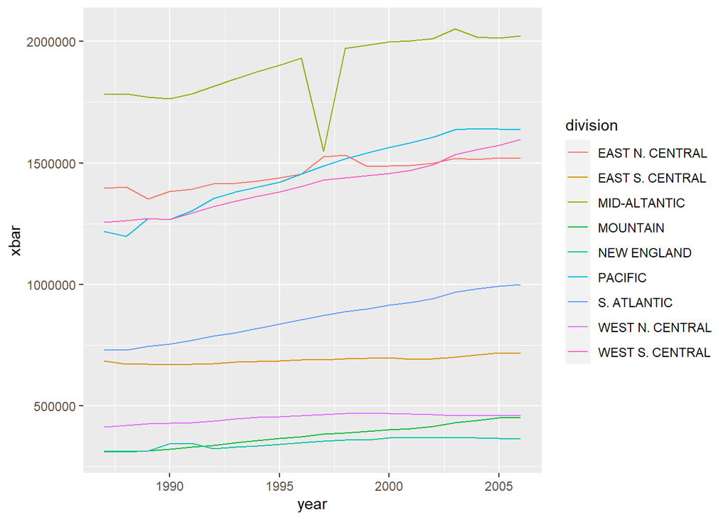

```r
plot.state(state)
```

4. *Use the plot function on the `county` data frame.*
- state: `'PA'`, rank: `'top'`, and n: `7`
- state: `'PA'`, rank: `'bottom'`, and n: `4`
- Using all default values
- state: `'MN'`, rank: `'top'`, and n: `10`

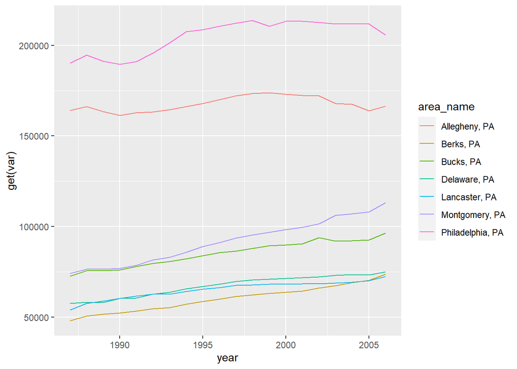

```r
plot.county(county, st = 'PA', rank = 'top', n = 7)
```

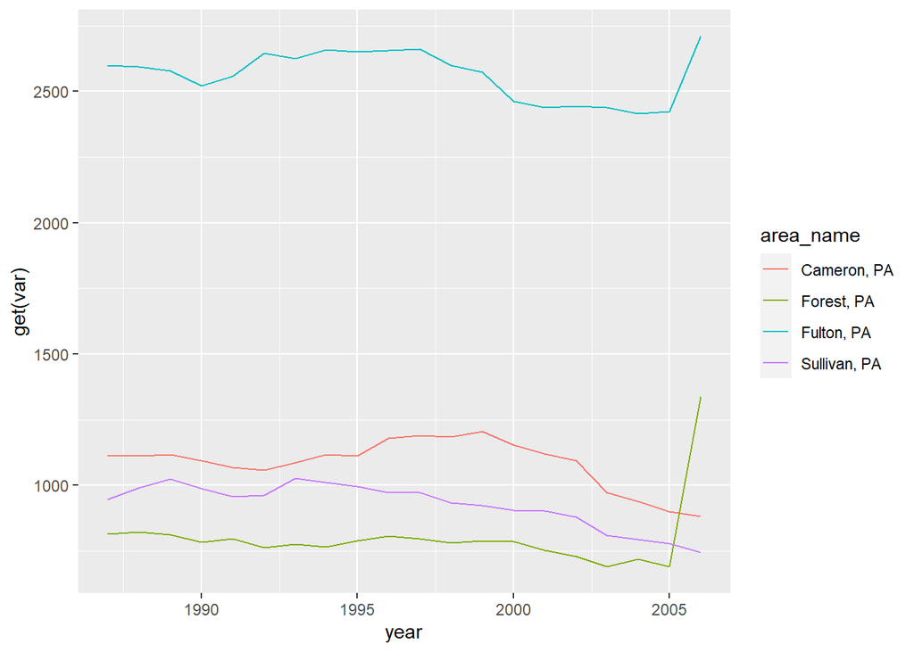

```r
plot.county(county, st = 'PA', rank = 'bottom', n = 4)
```

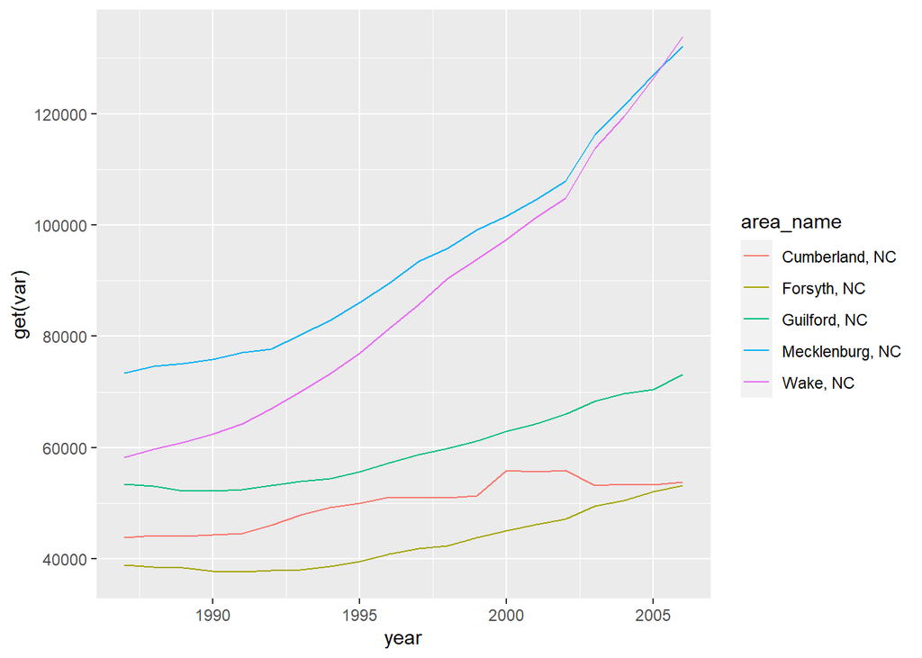

```r
plot.county(county)
```

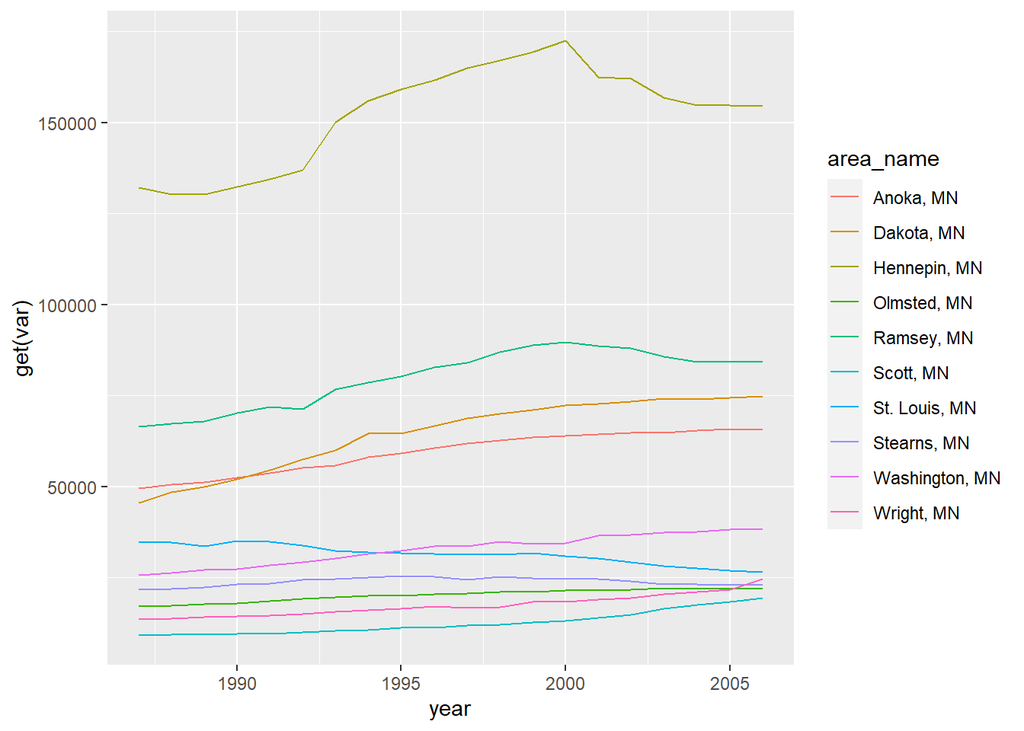

```r
#left out rank this time for default value
plot.county(county, st = 'MN', n = 10)
```

As resounding success all around! Lastly, we will apply the functions to new–but similarly formatted–data sets.

1. *Run your data processing function on the four data sets at the given URLs.*

```r
PSTa <- data.wrap("https://www4.stat.ncsu.edu/~online/datasets/PST01a.csv", var = "enrollment")
PSTb <- data.wrap("https://www4.stat.ncsu.edu/~online/datasets/PST01b.csv", var = "enrollment")
PSTc <- data.wrap("https://www4.stat.ncsu.edu/~online/datasets/PST01c.csv", var = "enrollment")
PSTd <- data.wrap("https://www4.stat.ncsu.edu/~online/datasets/PST01d.csv", var = "enrollment")
```

2. *Run your data combining function (probably three times) to put these into one object (with two data frames).*

```r
alpha <- lvl.combine(PSTa, PSTb)
beta <- lvl.combine(PSTc, PSTd)

all_PST <- lvl.combine(alpha, beta)

PST_state <- all_PST[[2]]
PST_county <- all_PST[[1]]
```

3. *Use the plot function on the state data frame.*

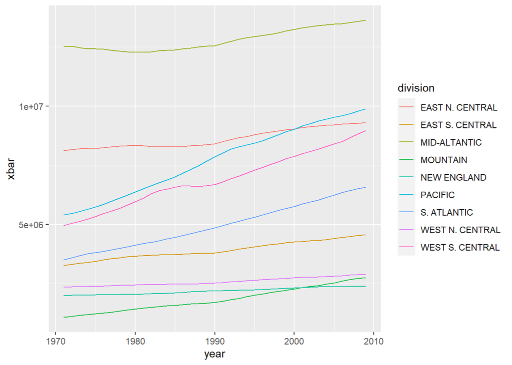

```r
plot.state(PST_state)
```

4. *Use the plot function on the county data frame.*
- state: `'CT'`, rank: `'top'`, and n: 6
- state: `'NC'`, rank: `'bottom'`, and n: 10
- Using all default values
- state: `'MN'`, rank: `'top'`, and n: 4

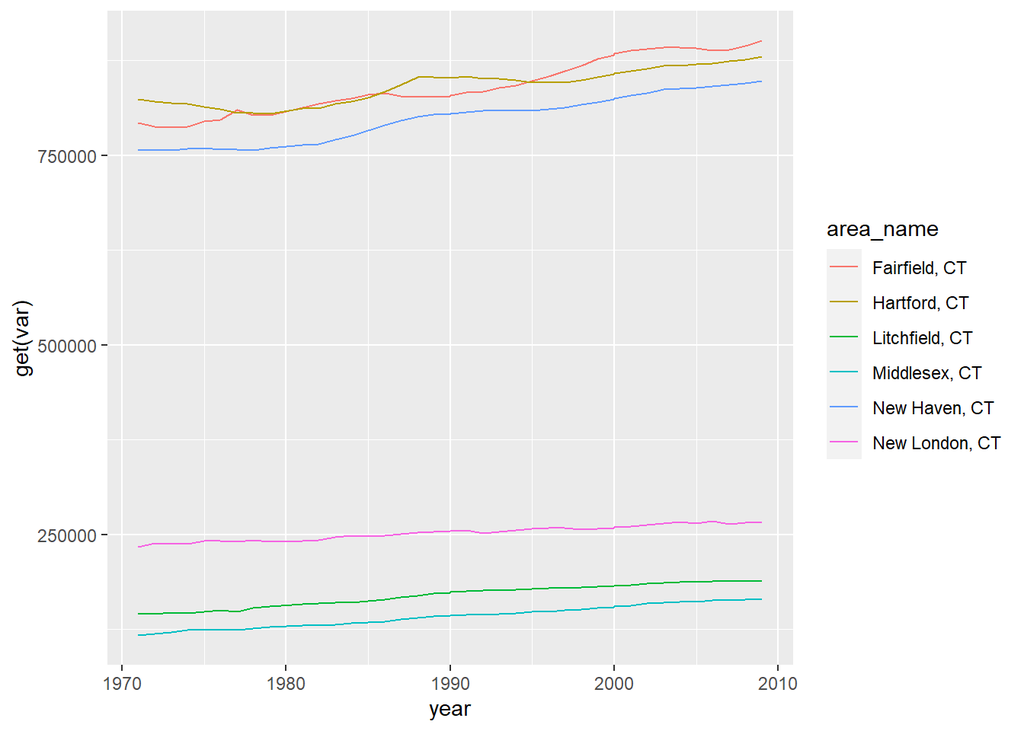

```r
plot.county(PST_county, st = 'CT', rank = 'top', n = 6)
```

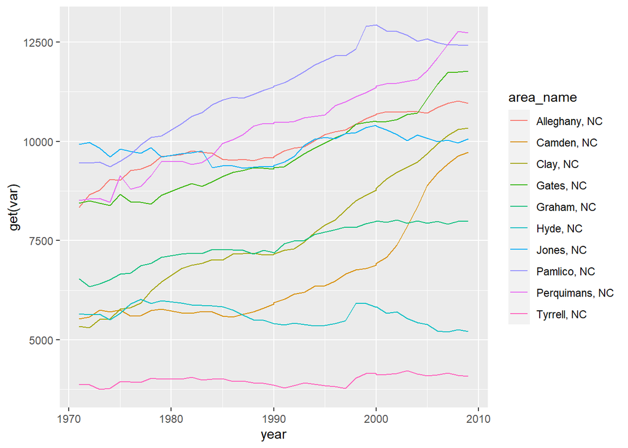

```r
#NC left out since it's the default
plot.county(PST_county, rank = 'bottom', n = 10)
```

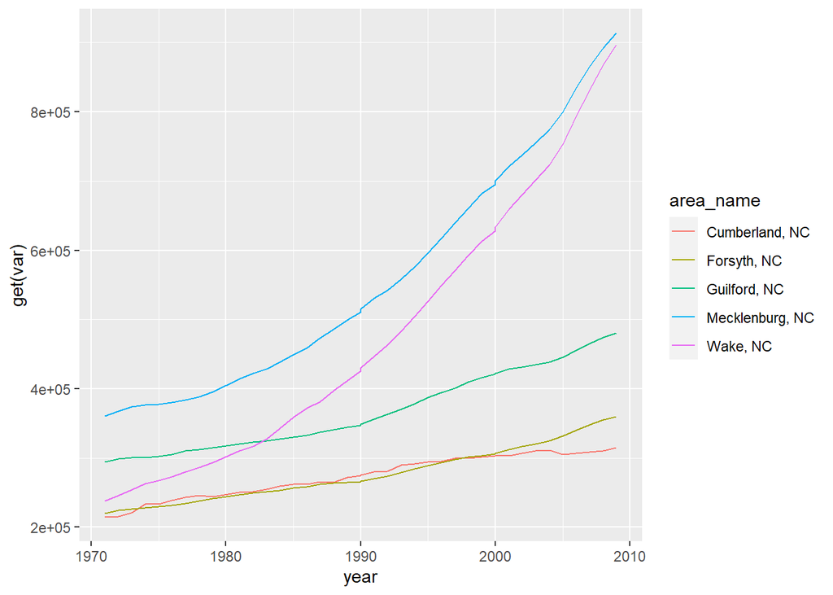

```r
plot.county(PST_county)
```

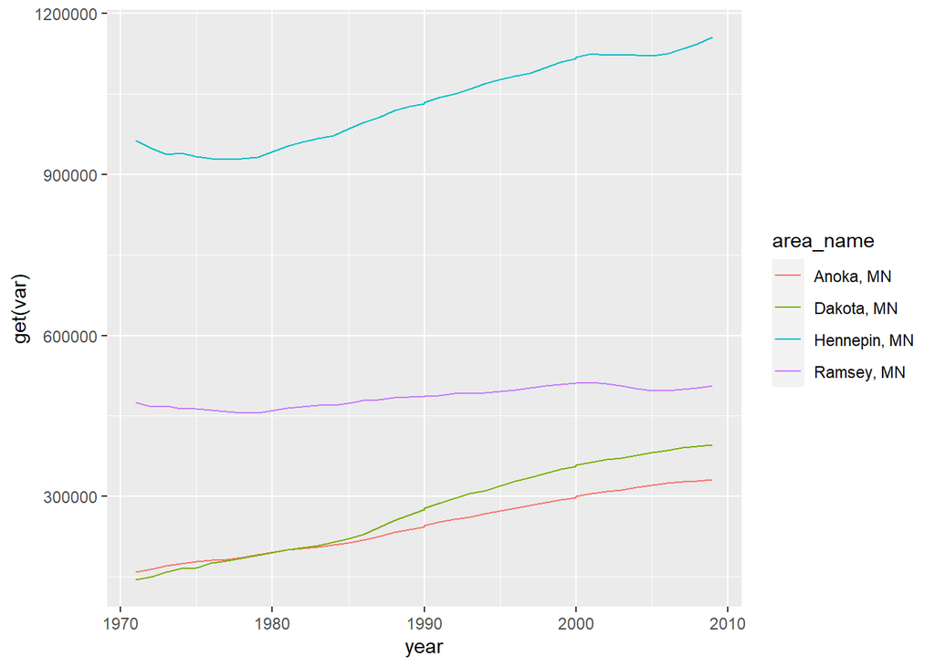

```r
plot.county(PST_county, st = 'MN', rank = 'top', n = 4)
```

Back to top